# Lab 1

Daniel Yowell

2023-08-28

# Tasks

This is Lab 1

## Task 1

We need the working directory

```r
getwd()
```

```
## [1] "C:/Users/dyowe/Documents/「OU」/CLASSES/Statistics/Lab1"
```

## Task 2

Read in the DDT data

```r
ddt <- read.csv("DDT.csv")
head(ddt)
```

```
##   RIVER MILE  SPECIES LENGTH WEIGHT DDT
## 1   FCM    5 CCATFISH   42.5    732  10
## 2   FCM    5 CCATFISH   44.0    795  16
## 3   FCM    5 CCATFISH   41.5    547  23
## 4   FCM    5 CCATFISH   39.0    465  21
## 5   FCM    5 CCATFISH   50.5   1252  50
## 6   FCM    5 CCATFISH   52.0   1255 150
```

## Task 3

Qualitative variables: RIVER, SPECIES Quantitative variables: MILE, LENGTH, WEIGHT, DDT Number of Species: 3

Subset 1:

```r
library(dplyr)
subset1 <- ddt %>% filter(SPECIES == 'LMBASS' & WEIGHT > 800)
subset1
```

```
##   RIVER MILE SPECIES LENGTH WEIGHT DDT
## 1   TRM  345  LMBASS     30    856 2.2
## 2   TRM  345  LMBASS     36   1433 1.9
```

Subset 2:

```r
subset2 <- ddt %>% filter(RIVER == 'SCM' & DDT > 4.0)
subset2
```

```
##   RIVER MILE  SPECIES LENGTH WEIGHT DDT
## 1   SCM    1 CCATFISH     45    984 9.1
## 2   SCM    1 CCATFISH     43    965 7.8
## 3   SCM    1 CCATFISH     45   1084 4.1
```

## Task 4

Q.1 Find the mean length of fish in the ddt data frame.

```r
mean_length <- mean(ddt$LENGTH)
mean_length
```

```
## [1] 42.8125
```

Q.2 What is the standard deviation of the weight of fish in the ddt data frame?

```r
sd_weight <- sd(ddt$WEIGHT)
sd_weight
```

```
## [1] 376.5461
```

Q.3 Is this the plot of LENGTH vs WEIGHT from the ddt data frame?

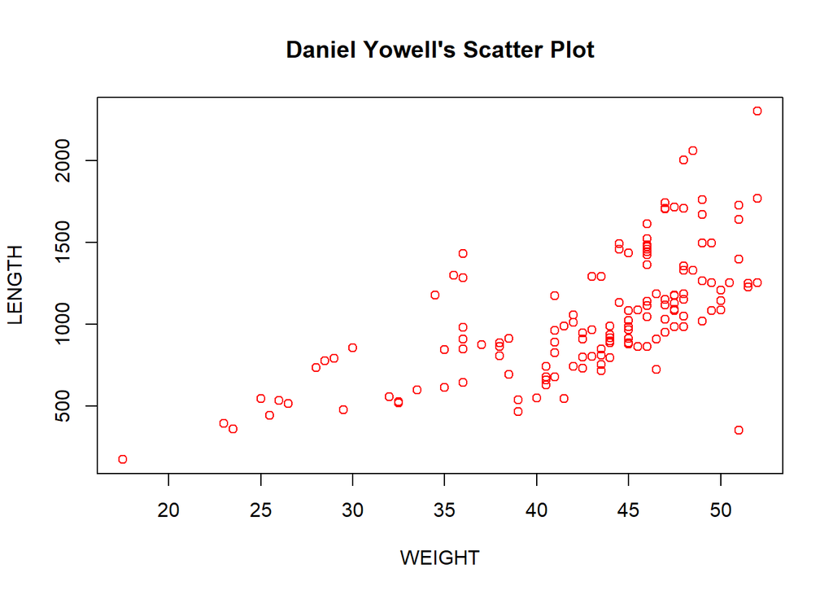

```r
plot(ddt$LENGTH, ddt$WEIGHT, main="Daniel Yowell's Scatter Plot", xlab="WEIGHT", ylab="LENGTH", col="red")
```

1

Q.4 If v=1:20 what is the last value of v/20?

```r
v=1:20
v/20
```

```
##  [1] 0.05 0.10 0.15 0.20 0.25 0.30 0.35 0.40 0.45 0.50 0.55 0.60 0.65 0.70 0.75
## [16] 0.80 0.85 0.90 0.95 1.00
```

The last value is 1.00

## Task 5

Make a table of the rivers.

```r
summary_table <- ddt %>% group_by(RIVER) %>% summarize(Count = n(),)
summary_table
```

```
## # A tibble: 4 × 2
##   RIVER Count
##   <chr> <int>
## 1 FCM       6
## 2 LCM       6
## 3 SCM       6
## 4 TRM     126
```

Make a color-coded barplot of the rivers.

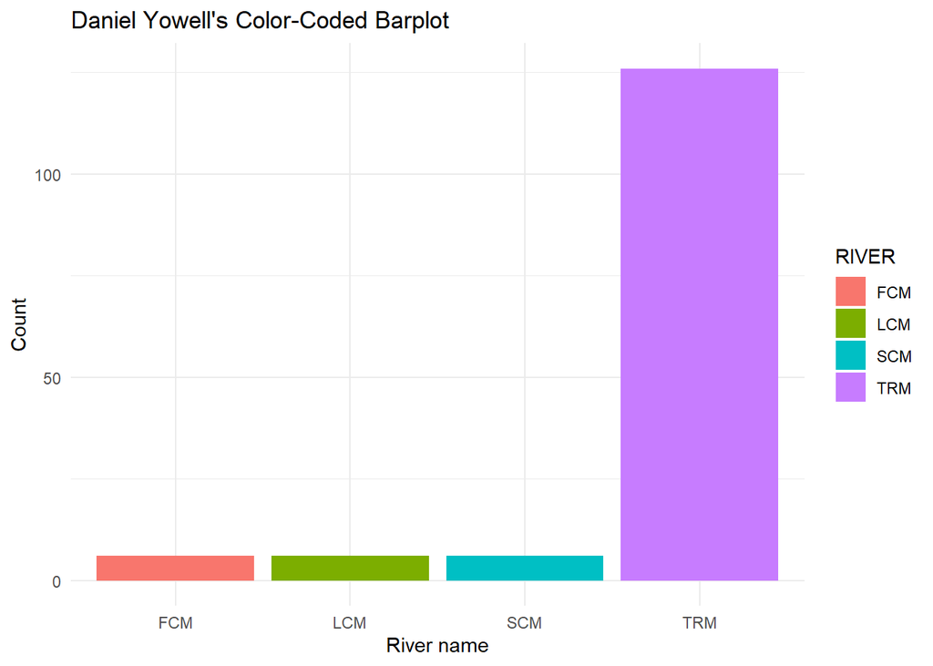

```r
library(ggplot2)
ggplot(ddt, aes(x = RIVER, fill = RIVER)) +
  geom_bar() +
  labs(title = "Daniel Yowell's Color-Coded Barplot",
       x = "River name",
       y = "Count") +
  theme_minimal()
```

Make a table of the rivers crossed with the species of fish.

```r
cross_table1 <- table(ddt$RIVER, ddt$SPECIES)
print(cross_table1)
```

```
##
##       CCATFISH LMBASS SMBUFFALO
##   FCM        6      0         0
##   LCM        6      0         0
##   SCM        6      0         0
##   TRM       78     12        36
```

Make a barplot of the rivers crossed with the species of fish.

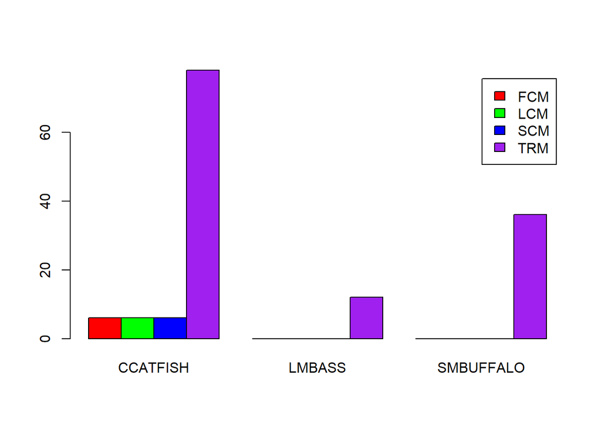

```r
cross_table2 <- table(ddt$RIVER, ddt$SPECIES)
bar_plot_colors <- c("red", "green", "blue", "purple")
barplot(cross_table2, beside = TRUE, legend = rownames(cross_table2), col = bar_plot_colors)
```

## Task 6

Make a pie chart of Fish SPECIES

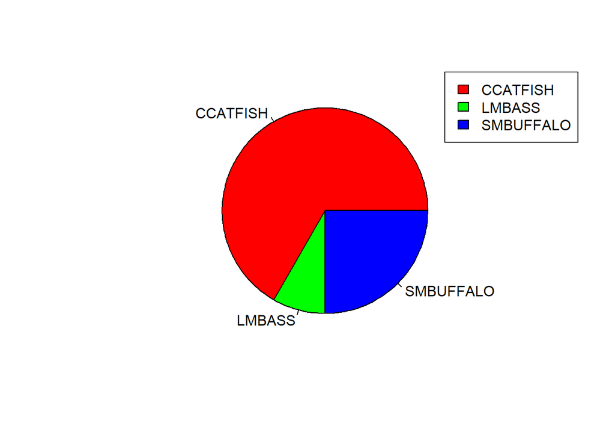

```r
# first count the # of species, then plot that
library(dplyr)
summary_table <- ddt %>%
                group_by(SPECIES) %>%
                summarize(
                  Count = n(),
                )
pie_chart_labels <- summary_table$SPECIES
pie_chart_colors <- c("red", "green", "blue", "purple")
pie(summary_table$Count, labels = pie_chart_labels, col = pie_chart_colors)
legend("topright", legend = pie_chart_labels, fill = pie_chart_colors)
```

Make a pie chart of RIVERS

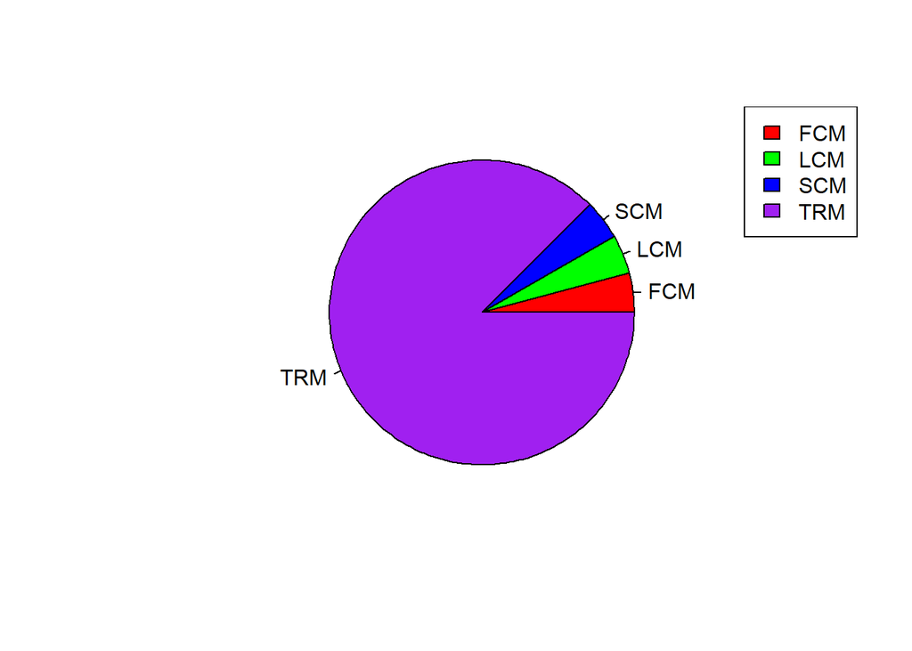

```r
library(dplyr)
summary_table <- ddt %>%
                group_by(RIVER) %>%
                summarize(
                  Count = n(),
                )
pie_chart_labels <- summary_table$RIVER
pie_chart_colors <- c("red", "green", "blue", "purple")
pie(summary_table$Count, labels = pie_chart_labels, col = pie_chart_colors)
legend("topright", legend = pie_chart_labels, fill = pie_chart_colors)
```

## Task 7

Make a boxplot of the variable DDT

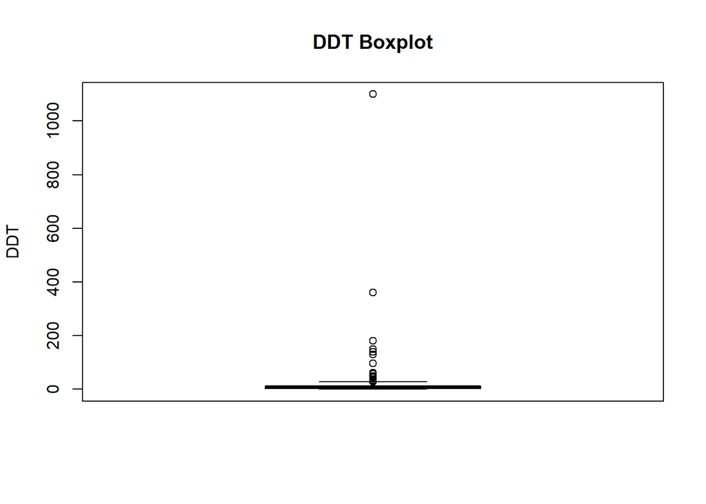

```r
boxplot(ddt$DDT, main="DDT Boxplot", ylab="DDT")
```

Make a boxplot of the variable WEIGHT

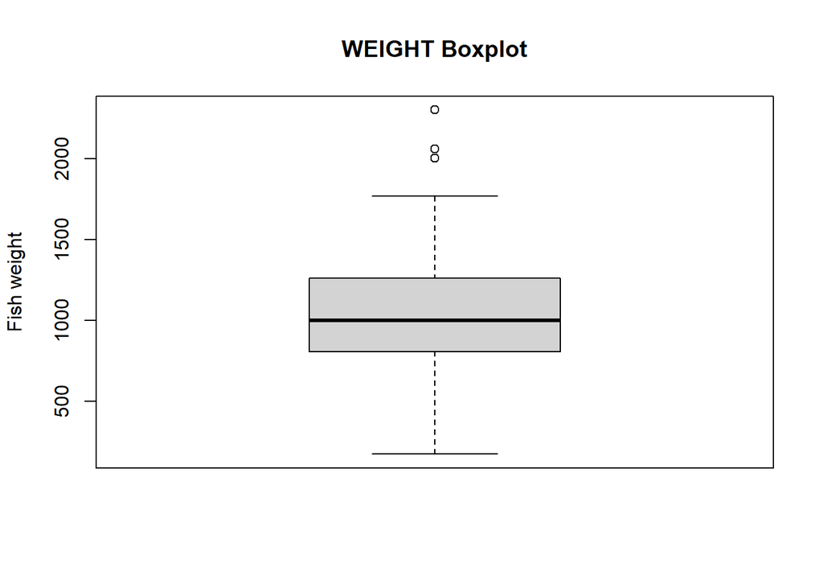

```r
boxplot(ddt$WEIGHT, main="WEIGHT Boxplot", ylab="Fish weight")
```

Make a boxplot of the variable LENGTH

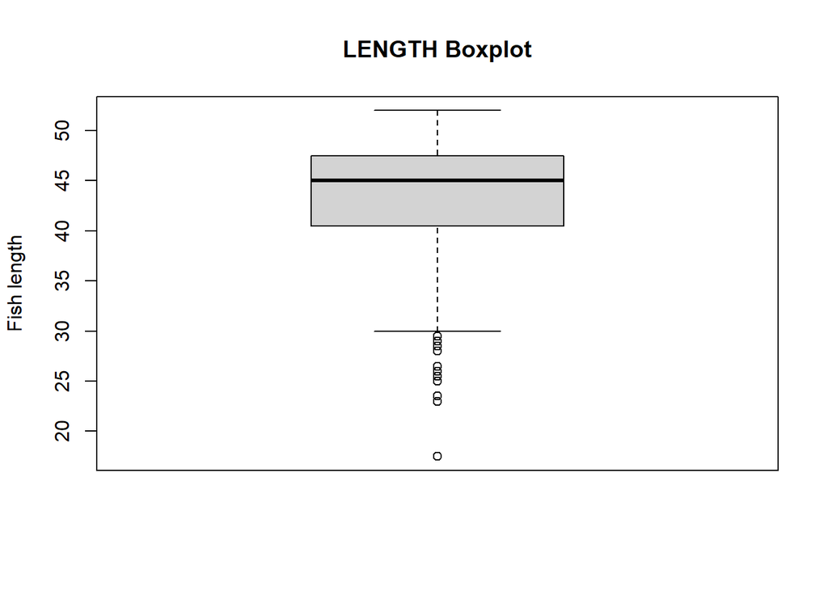

```r
boxplot(ddt$LENGTH, main="LENGTH Boxplot", ylab="Fish length")
```